# R Plot Annotation (mostly ggplot2)

Jamie Reilly, Ph.D.

2018-08-07

# Introduction

R has a steep learning curve. It is often useful to cannibalize and modify someone else’s code rather than starting from scratch. I hope this page offers just such a resource. If you have a plot that you are particularly proud of, please feel free to send me the code. I will post it here and acknowledge you as author.

Often half the battle of R is reading the data in. If you plan to share a code snippet, consider posting your data to a public repository. You can send a link, and R will read the data in. This obviates unique working directories for each user. The ‘read_csv’ command from the readr library works pretty well. You can also link to Google Drive or a similar public URL, but Github seems to work the smoothest.

Here’s sample code that successfully reads data in from a CSV file posted on my lab’s Github repository.

```r
url.dat <- read_csv("https://raw.githubusercontent.com/reilly-lab/reilly-lab.github.io/master/BoyGirl.csv",
    col_names = TRUE)
```

Here are some libraries we will be using.

```r
library(reshape2)
library(tidyverse)
library(readr)
library(formatR)
library(knitr)
library(gplots)
library(corrplot)
library(tibble)
library(RColorBrewer)
library(data.table)
library(splitstackshape)
library(ggdendro)
```

# A custom theme for ggplot2

Here’s a minimalist home brew of a theme for ggplot2. I’ll add this to most of the plots to follow. It strips panel gridlines and all sorts of other default junk.

```r
jamie.theme <- theme_bw() + theme(axis.line = element_line(colour = "black"),
    panel.grid.minor = element_blank(), panel.grid.major = element_blank(),
    panel.border = element_blank(), panel.background = element_blank(), legend.title = element_blank())
```

# Axis adjustments (limits, breaks, etc.)

ggplot2 can be a bit challenging regarding axes. Let’s first generate a dataframe populated with randomly sampled data from 1-100 without replacement. Then plot it.

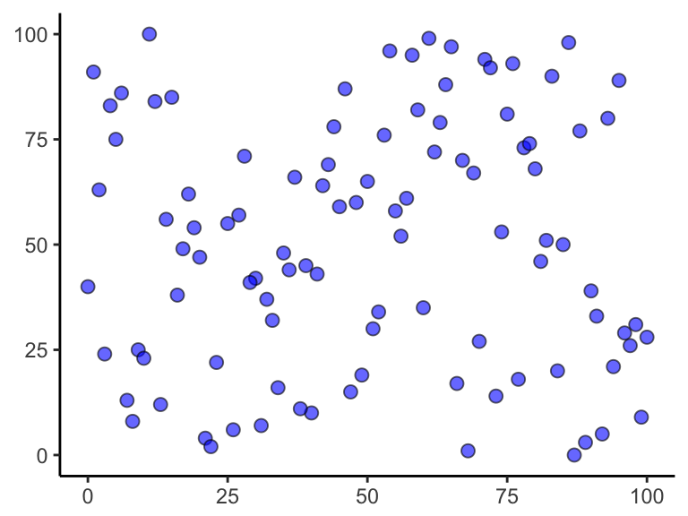

```r
set.seed(999)  #fixed random sampling
dat <- data.frame(replicate(2, sample(0:100, 100, rep = F)))  #selection without replacement
baseplot <- ggplot(dat, aes(X1, X2)) + geom_point(shape = 21, fill = "blue",
    size = 2.3, alpha = 0.6) + jamie.theme + ylab(NULL) + xlab(NULL)
print(baseplot)
```

## Specify user-defined axis breaks

Yuck. We need finer-grained notation on both axes. Add breaks every 10.

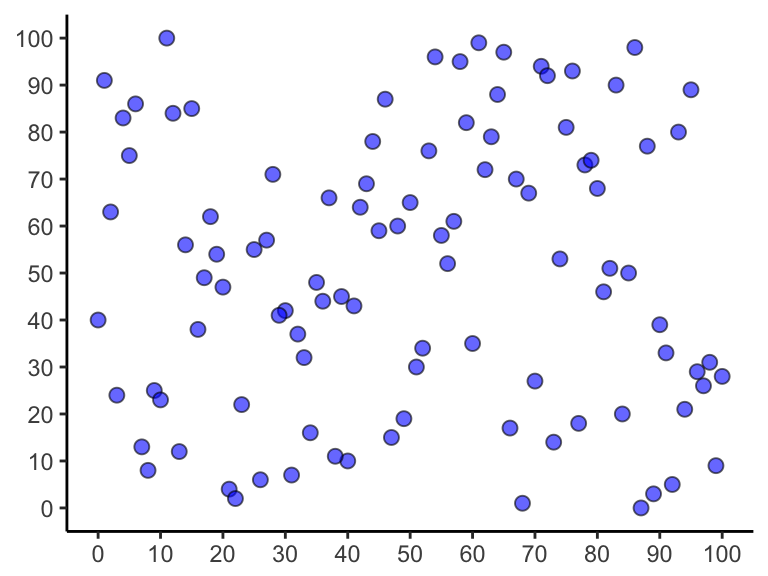

```r
newplot <- baseplot + scale_x_continuous(breaks = seq(0, 100, 10), limits = c(0,
    100)) + scale_y_continuous(breaks = seq(0, 100, by = 10))
print(newplot)  #scale continuous is seq(from,to,by)
```

## Set axis limits manually

xlim and ylim can cut off data. Tread lightly. Here is what xlim=50 looks like.

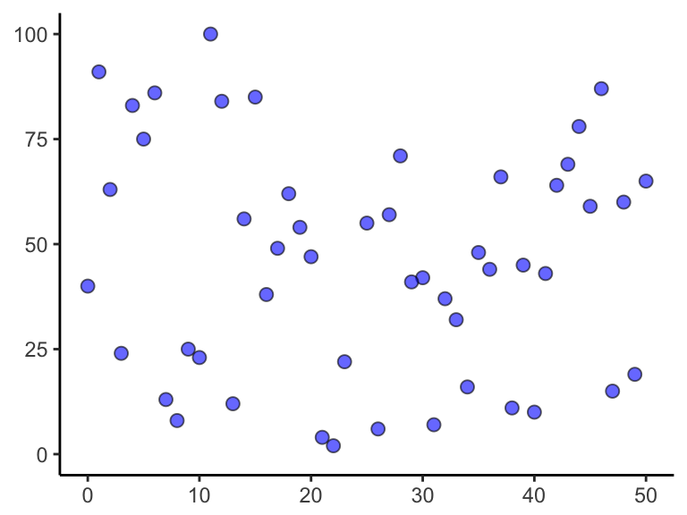

```r
smaller <- baseplot + xlim(c(0, 50))
print(smaller)
```

## Zoom in on a specific range using coord_cartesian

This zooms on a specific range without cutting/eliminating data

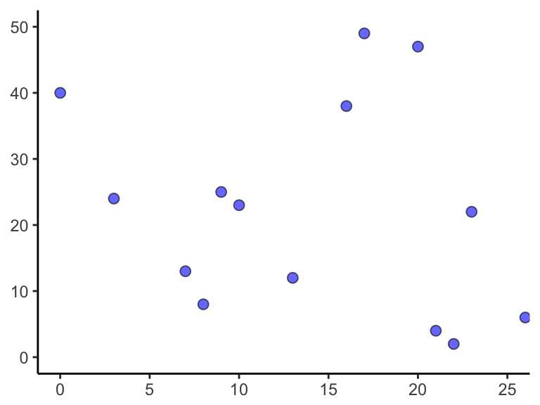

```r
focused <- baseplot + coord_cartesian(xlim = c(0, 25), ylim = c(0, 50))
print(focused)
```

# Scatterplots

## Barplot and boxplot alternative

Here’s a nice alternative to boxplots, reflecting individual differences in average uncorrected pupil diameters for a bunch of neurotypical adults measured in very bright, medium, and dark ambient light. Conditions are colored by a custom vector (in code block below as ‘newvec’). Here are the first 5 rows of the molten dataframe.

```r
scat.raw <- read.csv("Exp2_PlotUncorrected.csv", header = T)
scat.raw.melt <- scat.raw %>% melt(measure.vars = 2:4)
head(scat.raw.melt, n = 5)
```

```
##   participant variable    value
## 1           2      low 3.861133
## 2           3      low 3.713745
## 3           4      low 4.012212
## 4           5      low 4.004413
## 5           6      low 4.000240
```

plot it. the tricky part is getting R to plot the crossbars as means.

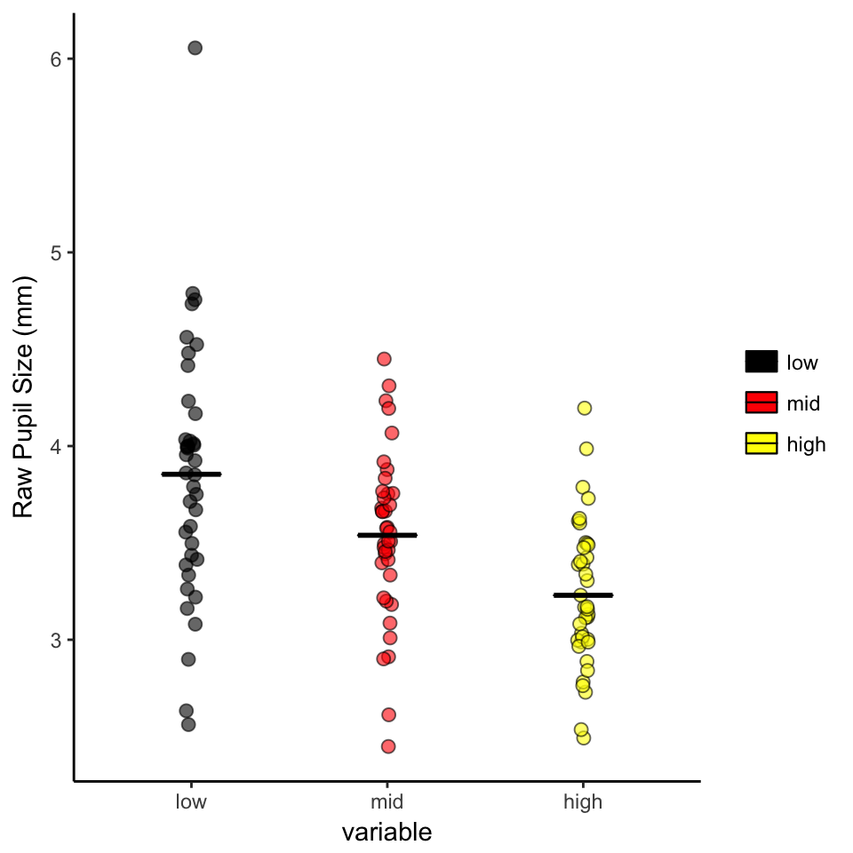

```r
newvec <- c("black", "red", "yellow")
ggplot(scat.raw.melt, aes(variable, value, shape = variable, fill = variable)) +
    geom_point(shape = 21, color = "black", size = 2.3, alpha = 0.6, position = position_jitter(w = 0.03,
        h = 0)) + scale_fill_manual(values = newvec) + ylab("Raw Pupil Size (mm)") +
    stat_summary(fun.y = mean, fun.ymin = mean, fun.ymax = mean, geom = "crossbar",
        color = "black", size = 0.4, width = 0.3) + jamie.theme
```

## smoothed trendline

To all the naysayers who argue that word concreteness & imageability are wildly different, this scatterplot shows their correlation across many nouns from the MRC Psycholinguistic Database. For some reason CNC gets read in as a factor and must be coerced to integer for this to work. The smoother here uses a Loess function. Since N>1000, this is probably ok.

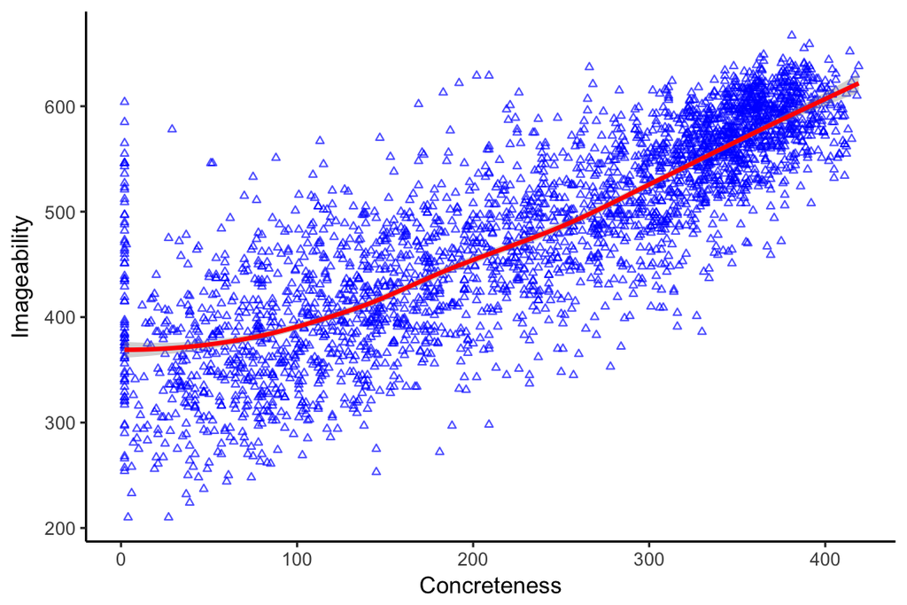

```r
cnc <- read.csv("ImgBigSet.csv", header = T)
cnc$CNC <- as.integer(cnc$CNC)
ggplot(cnc, aes(x = CNC, y = IMG)) + geom_point(shape = 2, size = 1, color = "Blue",
    alpha = 0.7) + stat_smooth(method = loess, color = "red") + xlab("Concreteness") +
    ylab("Imageability") + scale_x_continuous(breaks = seq(0, 600, by = 100)) +
    scale_y_continuous(breaks = seq(0, 600, by = 100)) + jamie.theme
```

## scatterplots facet-wrapped & axis scaled free

This plot also has some nice jitter, colors, and opacity on the points.These data represent different measures of pupil size. Some steps in structuring the data….

```r
scat2 <- read.csv("Exp2_Scattersetup_2.0.csv", header = T)
scat.m <- scat2 %>% melt(id.vars = 5, measure.vars = 2:4)  #melt the original dataframe to long form
scat.m$variable <- factor(scat.m$variable, levels = c("low", "mid", "high"))  #reorder the factors
head(scat.m, n = 10)
```

```
##    condition variable       value
## 1       Peak     high  0.39775642
## 2       Peak     high  0.26944261
## 3       Peak     high  0.09137426
## 4       Peak     high  0.35118977
## 5       Peak     high  0.09760123
## 6       Peak     high  0.14468570
## 7       Peak     high -0.04490110
## 8       Peak     high  0.08113402
## 9       Peak     high  0.08560565
## 10      Peak     high  0.04926434
```

Now plot it facetting by condition. NB all the y-axis have different scales and must scale free.

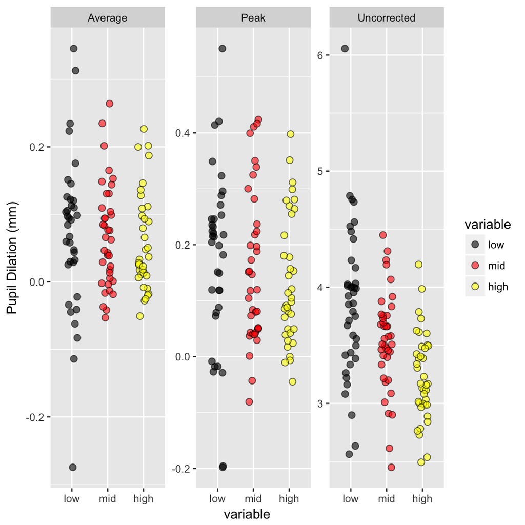

```r
newvec <- c("black", "red", "yellow")
scat.facet <- ggplot(scat.m, aes(variable, value, shape = variable, fill = variable)) +
    geom_point(shape = 21, color = "black", size = 2.3, alpha = 0.6, position = position_jitter(w = 0.17,
        h = 0)) + scale_fill_manual(values = newvec) + facet_wrap(~condition,
    scales = "free_y") + ylab("Pupil Dilation (mm)")
scat.facet
```

# Line graphs & time series plots

## time series plot of the human pupillary response

These curves reflect three response functions of baseline corrected change in pupil size (in mm) elicited during a word monitoring task when people stare at either an unchanging gray screen in darkness, mid-level luminance, or obnoxiously bright light. The data are in long form, factors are reordered (dark, mid, bright).

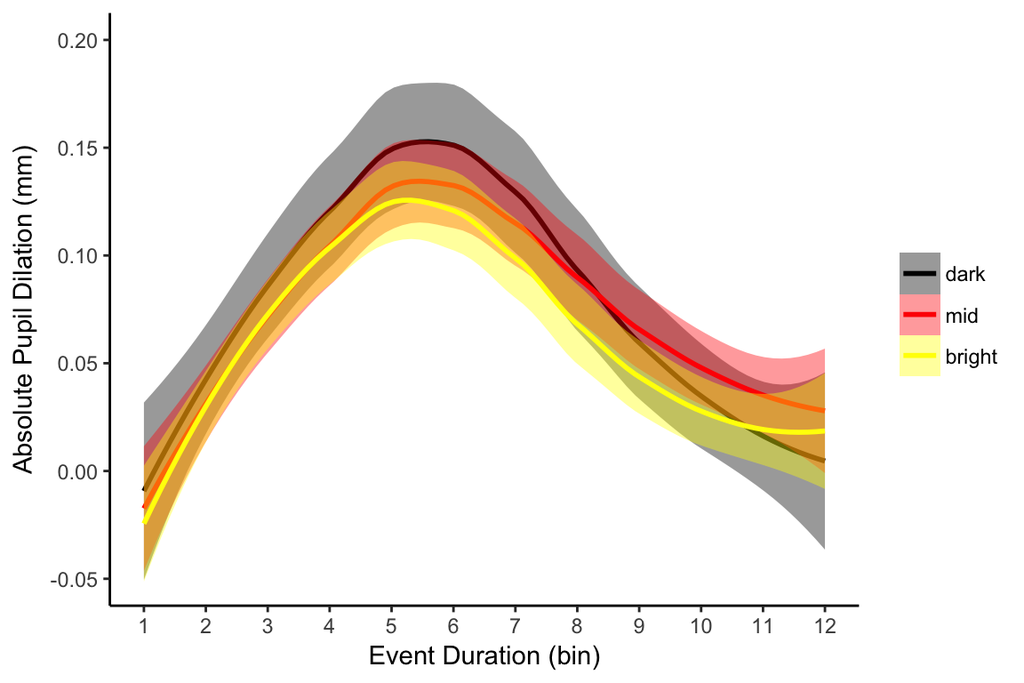

```r
summary.words <- read.csv("Exp2_RSetupPostPipeline_1.0.csv", header = T)
summary.words$lightCond <- factor(summary.words$lightCond, levels = c("dark",
    "mid", "bright"))
newvec <- c("black", "red", "yellow")
pupils <- ggplot(summary.words, aes(x = bin, y = raw.diff, color = lightCond,
    fill = lightCond)) + geom_smooth(method = loess, alpha = 0.4) + scale_colour_manual(values = newvec) +
    scale_fill_manual(values = newvec) + coord_cartesian(ylim = c(-0.05, 0.2)) +
    coord_cartesian(ylim = c(-0.05, 0.2)) + ylab("Absolute Pupil Dilation (mm)") +
    xlab("Event Duration (bin)") + scale_x_continuous(breaks = pretty(summary.words$bin,
    n = 12)) + jamie.theme
print(pupils)
```

## facetted & smoothed line graph

This is a pretty little multiplot ofa study now underway where Spanish-English speakers rate emotional salience, color, etc. for the same set of words (translation equivalents) once in Spanish and a week later again in English. First steps are to get the data read in and in a form we can use for passing to ggplot2.

```r
raw <- read.csv("Biling_Master_v10.csv", header = T)
raw_cond <- raw %>% select(3, 13, 22:27)  #select the range of columns we need
cond_melt <- raw_cond %>% melt(id.vars = c(1, 2))  #melt into long form
head(cond_melt, n = 15)
```

```
##      Condition CNC.av variable value
## 1  Monolingual  2.915    Color     1
## 2  Monolingual  2.730    Color     1
## 3  Monolingual  3.000    Color     1
## 4  Monolingual  2.300    Color     1
## 5  Monolingual  3.005    Color     7
## 6  Monolingual  5.535    Color     6
## 7  Monolingual  2.190    Color     1
## 8  Monolingual  4.755    Color     1
## 9  Monolingual  4.860    Color     7
## 10 Monolingual  5.450    Color     1
## 11 Monolingual  4.810    Color     7
## 12 Monolingual  4.960    Color     6
## 13 Monolingual  4.690    Color     3
## 14 Monolingual  4.970    Color     7
## 15 Monolingual  5.580    Color     4
```

Plot it.

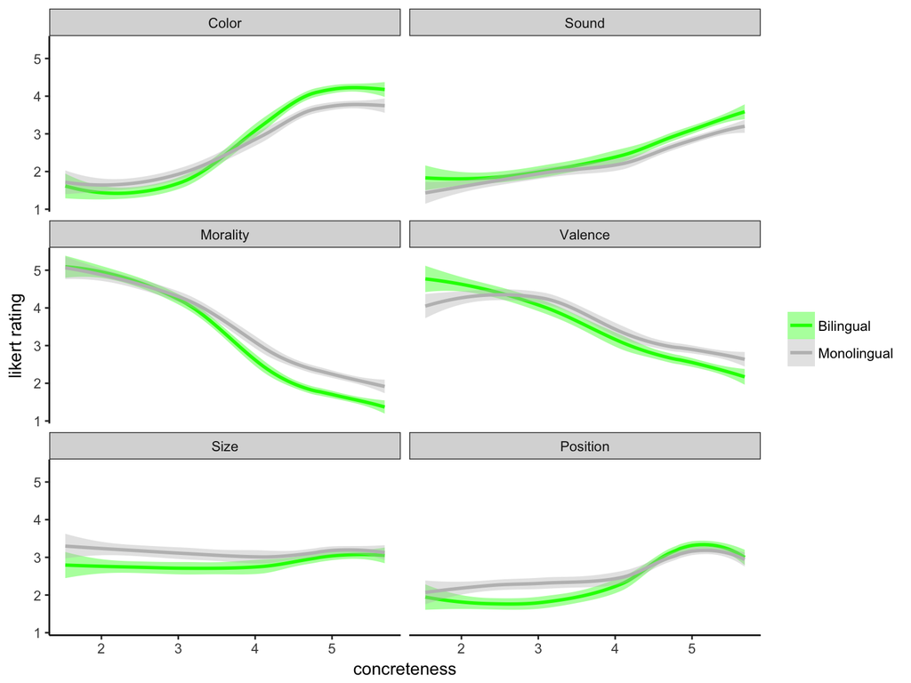

```r
colslope <- c("green", "gray")  #creates a vector of colors to pass to aes
ggplot(cond_melt, aes(x = CNC.av, y = value, fill = Condition, color = Condition)) +
    geom_smooth(method = "loess") + scale_fill_manual(values = colslope) + scale_color_manual(values = colslope) +
    facet_wrap(~variable, ncol = 2) + xlab("concreteness") + ylab("likert rating") +
    jamie.theme
```

## my sad saga of plotting and overlaying two time series

This was an attempt to overlay two time series reflecting 30seconds of pupillary measurement (sampling rate 120Hz) for two of my labbies (Jill and Liz). There are 3450 samples for Liz and Jill. The time series are non-stationary, and there are missing observations associated with blinks. Let’s look at the raw data.

```r
pup <- read.csv("pup_raw.csv", header = T)
head(pup, n = 4)
```

```
##    liz jill
## 1 4.45 5.10
## 2 4.45 5.08
## 3 4.45 5.07
## 4 4.45 5.07
```

Melt the dataframe into long form.

```r
pup.m <- pup %>% melt(measure.vars = 1:2, value.name = "pupil.size", variable.name = "labbie")
head(pup.m, n = 4)  #hmmm.... need to add a counter variable to plot along x-axis
```

```
##   labbie pupil.size
## 1    liz       4.45
## 2    liz       4.45
## 3    liz       4.45
## 4    liz       4.45
```

I’m stuck. I have a long vector of pupil diameters (y-values), but there are no corresponding x-axis values. I need to create a sequence of numbers 1-length(x) by each level of the factor. I looked at seq_along and a few other options and realized I had no idea how to do this. Deep breath. If I can get something to work on a teeny dataframe, it’ll scale up to this big time series, right?

```r
vec1 <- c(rep("a", 5), rep("b", 5))
vec2 <- c(6, 9, NA, 1, 3, NA, 8, 2, 10, NA)
dat <- data.frame(cbind(vec1, vec2))
dat$vec2 <- as.numeric(dat$vec2)
dat
```

```
##    vec1 vec2
## 1     a    5
## 2     a    7
## 3     a   NA
## 4     a    1
## 5     a    4
## 6     b   NA
## 7     b    6
## 8     b    3
## 9     b    2
## 10    b   NA
```

```r
dat$try <- seq_along(dat$vec1)
dat
```

```
##    vec1 vec2 try
## 1     a    5   1
## 2     a    7   2
## 3     a   NA   3
## 4     a    1   4
## 5     a    4   5
## 6     b   NA   6
## 7     b    6   7
## 8     b    3   8
## 9     b    2   9
## 10    b   NA  10
```

Burn. It didnt work. ‘try’ is just a sequence of 1-10 along the whole range ignoring the separate levels of the factor. After some Googling, I tried these different methods. Nothing worked. I almost resorted to writing a loop.

```r
dat$maybe <- with(dat, ave(vec2, FUN = seq_along))
dat$perhaps <- rleid(dat$vec1)
dat$whoknows <- sequence(rle(df$vec1)$lengths)
```

Then I recalled that REM song about ‘holding on’ and eventrually discovered the ‘getanID’ function from the splitstackshape package. Look what it does – behold the .id column - exactly what we need.

```r
print(dat.n <- getanID(data = dat, id.vars = "vec1"))
```

```
##     vec1 vec2 try .id
##  1:    a    5   1   1
##  2:    a    7   2   2
##  3:    a   NA   3   3
##  4:    a    1   4   4
##  5:    a    4   5   5
##  6:    b   NA   6   1
##  7:    b    6   7   2
##  8:    b    3   8   3
##  9:    b    2   9   4
## 10:    b   NA  10   5
```

Now that I know how that works, we can apply that function to our much longer time series to create a sampling variable.

```r
pup.numbered <- getanID(data = pup.m, id.vars = "labbie")  #creates a sequence of 1:Length(X) per level of grouping variable
# data.frame(pup.numbered) #changes the data table to a dataframe, probably
# not necessary
setnames(pup.numbered, ".id", "time")  #renames .id to 'time'
head(pup.numbered, n = 8)
```

```
##    labbie pupil.size time
## 1:    liz       4.45    1
## 2:    liz       4.45    2
## 3:    liz       4.45    3
## 4:    liz       4.45    4
## 5:    liz       4.45    5
## 6:    liz       4.45    6
## 7:    liz       4.44    7
## 8:    liz       4.45    8
```

Mission accomplished? Now let’s plot it. Sure it’s a bit ugly as most complex time series are. Needs interpolation and smoothing, but that’s for another time.

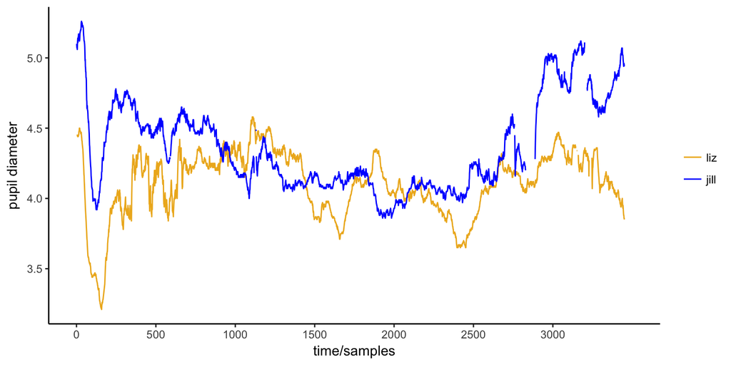

```r
mycols <- c("goldenrod2", "blue")
ggplot(pup.numbered, aes(x = time, y = pupil.size, color = labbie)) + geom_line() +
    scale_color_manual(values = mycols) + scale_x_continuous(breaks = seq(0,
    max(pup.numbered$time), by = 500), limits = c(0, 3500)) + ylab("pupil diameter") +
    xlab("time/samples") + jamie.theme
```

## generic line graph

Not much to say about this one. Just means across time. I eliminated the x-axis line and redrew it as dashed.

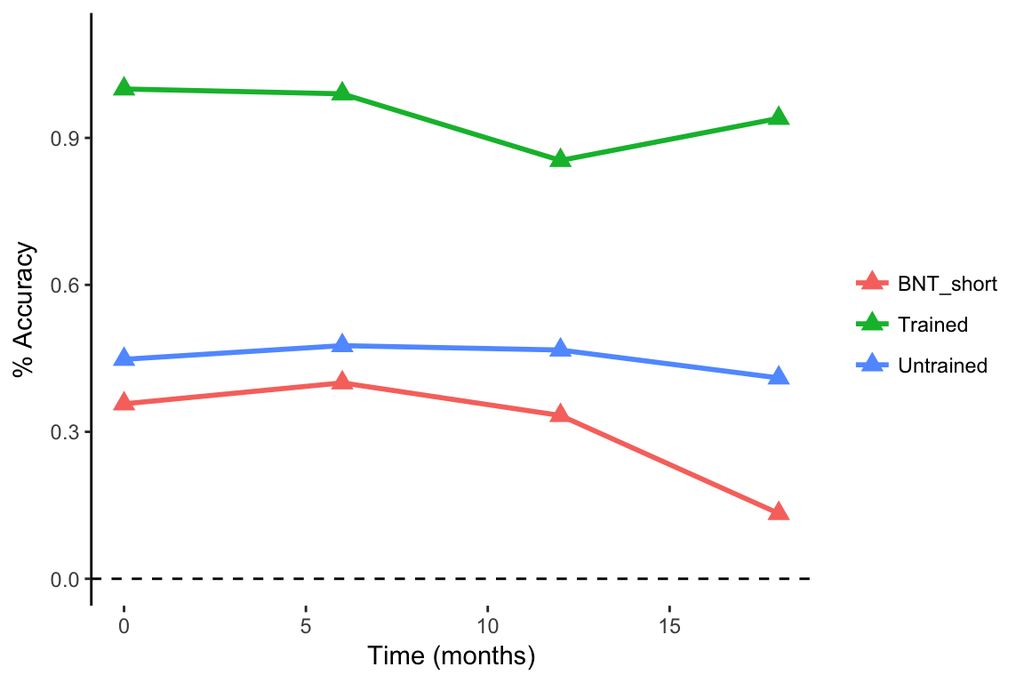

```r
lvppa <- read.csv("ancdsDat.csv", header = T)
ggplot(lvppa, aes(x = lvppa$Month, y = lvppa$Accuracy, colour = lvppa$Item)) +
    geom_line(size = 1) + theme_bw() + theme(axis.line = element_line(colour = "black"),
    panel.grid.minor = element_blank(), panel.border = element_blank(), panel.background = element_blank()) +
    coord_cartesian(ylim = c(0, 1.1)) + geom_hline(aes(yintercept = 0), linetype = "dashed") +
    theme(axis.line.x = element_blank()) + theme(panel.grid.major = element_blank(),
    panel.grid.minor = element_blank()) + ylab("% Accuracy") + xlab("Time (months)") +
    geom_point(shape = 17, size = 3) + labs(colour = "")
```

## Line graph with standard error bars: pupillary response to profanity

Here’s a line graph representing group level pupillary responses when people hear taboo words (e.g., dick) relative to matched but arousing anatomical terms (e.g., penis), and neutral terms (e.g., arm)

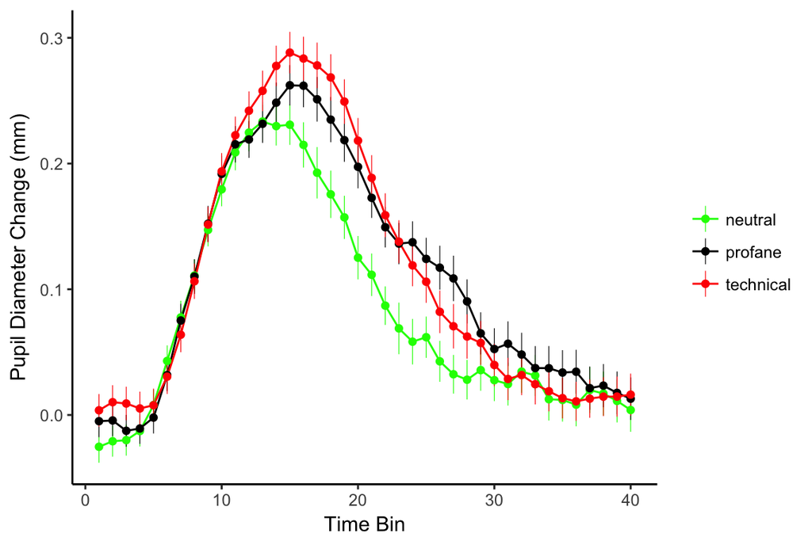

```r
pupcurse <- read.csv("exp1_pupilgood_noNW.csv", header = T)
# melts the original wide dataframe using columns 1-5 as measured vars and
# names the bin variable
pupmelt <- melt(pupcurse, id.vars = c("Subject", "Word", "WordID", "Condition",
    "Lexicality"), variable.name = "time_bin")
# changes time_bin variable from factor to numeric
pupmelt$time_bin <- as.numeric(pupmelt$time_bin)
# Plots word type line graph raw tim series: neutral, profane, technical
f3raw <- ggplot(pupmelt, aes(x = time_bin, y = value, color = Condition)) +
    stat_summary(fun.y = mean, geom = "line", size = 0.5) + scale_colour_manual(values = c("green",
    "black", "red")) + stat_summary(fun.data = mean_se, geom = "pointrange",
    size = 0.2) + theme_bw() + ylab("Pupil Diameter Change (mm)") + xlab("Time Bin") +
    theme(legend.position = c(0.85, 0.85)) + jamie.theme
print(f3raw)
```

## Plotting two pupil series using the stat_summary function

These are some interesting data from my former MA student Victoria Diedrichs’ thesis. These pupil response functions reflect Yes/No reponses when people thing of darkness (dark cave) associated with “No” and brightness (sunny day) associated with “Yes”

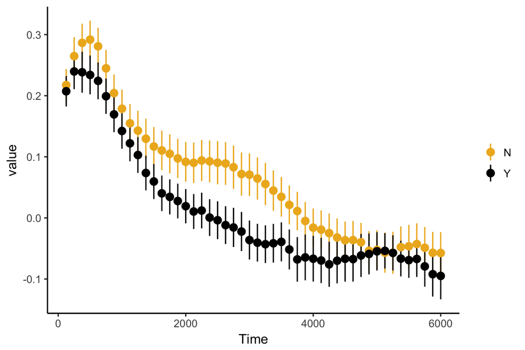

```r
pup.yes <- read_csv("BrightDark.csv")
pup.melt <- melt(pup.yes, id = 1:3)
pup.melt$Time <- 125 * (as.numeric(pup.melt$variable) - 1)
mycolors <- c("goldenrod2", "black")
ggplot(subset(pup.melt, Time > 0), aes(Time, value, color = COND)) + stat_summary(fun.data = mean_se,
    geom = "pointrange") + jamie.theme + scale_color_manual(values = mycolors)
```

# Histograms & Density Plots

## Change bin size and y-axis scale to counts

Here’s something you don’t see every day. This histogram reflects counts from Likert-Scale ratings of the quality of pairing common English nouns (e.g., rocket) with taboo words (e.g., shit) to form new taboo compounds (e.g., shitrocket). In this particular histogram, I changed the binwidth to .10 and the y-axis to raw counts.

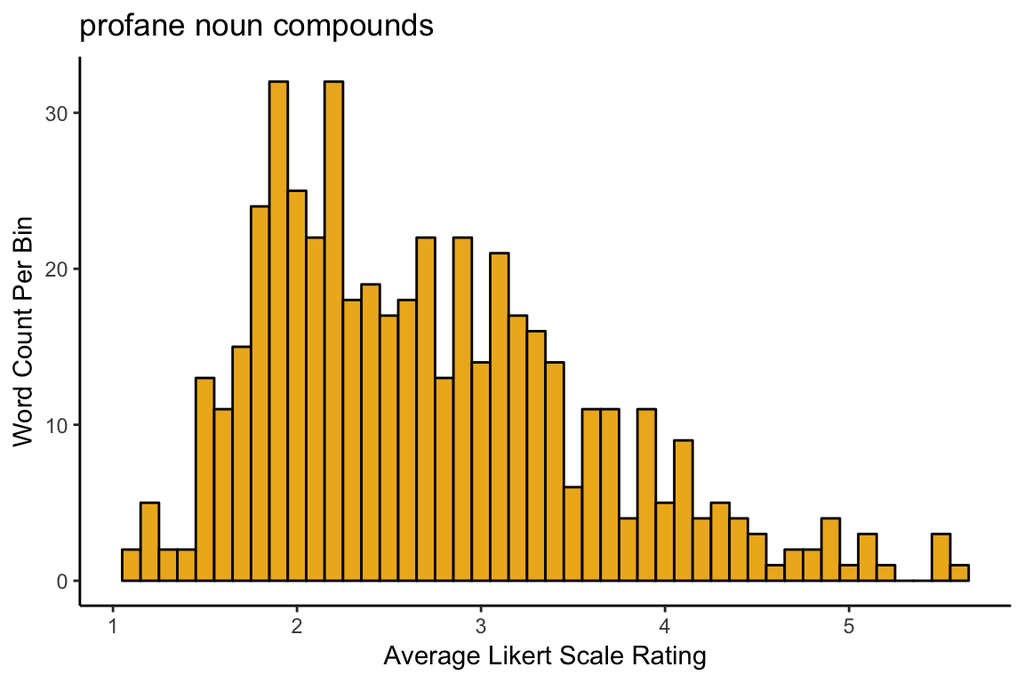

```r
profexp2 <- read.csv("ProfanityExp2_CleanR.csv", header = T)
histprof <- ggplot(profexp2, aes(x = profexp2$Qualtrics)) + geom_histogram(aes(y = ..count..),
    colour = "black", fill = "goldenrod2", binwidth = 0.1) + xlab("Average Likert Scale Rating") +
    ylab("Word Count Per Bin") + jamie.theme + ggtitle("profane noun compounds")
histprof
```

# Correlograms & Correlation Plots

## Correlogram

This one goes out to Dr. Joshua Troche, Assistant Professor at the University of Central Florida. Dr. Troche crowdsourced ratings from 300+ people on 16 semantic dimensions for 750 English words. The correlation matrices and plots to follow reflect the strength of the relationship(s) between factors like sound salience, visual form, loudness. For example, sound and visual form tend to be highly correlated when considering words like ‘dog’. Josh published this work in Frontiers in Human Neuroscience.

Coerce the first column to rownames or else you will get a big fat error when R tries to correlate a string with an integer.

```r
MDS_Corr <- read.csv("JoshCorr.csv", header = T, row.names = 1)
tib <- as_tibble(MDS_Corr)
print(tib)
```

```
## # A tibble: 751 x 16
##    Emotion Polarity Social Moral MotionSelf Thought Color TasteSmell
##  *   <dbl>    <dbl>  <dbl> <dbl>      <dbl>   <dbl> <dbl>      <dbl>
##  1    4.52     4.85   4.24  4.65        5.1    5.19   1.9       1.64
##  2    3.66     4.03   3.3   3.29        2.7    3.53   2.4       1.64
##  3    3.09     3.6    2.62  2.62        3.5    3.15   2.6       1.64
##  4    5.41     5.52   3.97  4.74        4.2    4.72   1.9       1.64
##  5    2.9      3.33   3.3   2.84        3.2    3.53   2         1.64
##  6    2.9      3.64   3.76  2.94        3.4    3.28   2         1.64
##  7    1.69     2.14   1.63  2.05        1.3    1.75   2.3       2.64
##  8    2.59     3.33   2.79  2.13        2      3.88   1.7       1.64
##  9    4.97     4.76   5.03  4.16        4.1    4.91   2         1.64
## 10    3.59     3.61   3.73  3.45        2.9    3.72   2.1       1.64
## # ... with 741 more rows, and 8 more variables: Tactile <dbl>,
## #   VisForm <dbl>, Auditory <dbl>, Space <dbl>, Quantity <dbl>,
## #   Time <dbl>, Concreteness <int>, Imageability <int>
```

```r
joshcor <- cor(MDS_Corr, use = "complete.obs")  #converts the dataframe to a correlation matrix
```

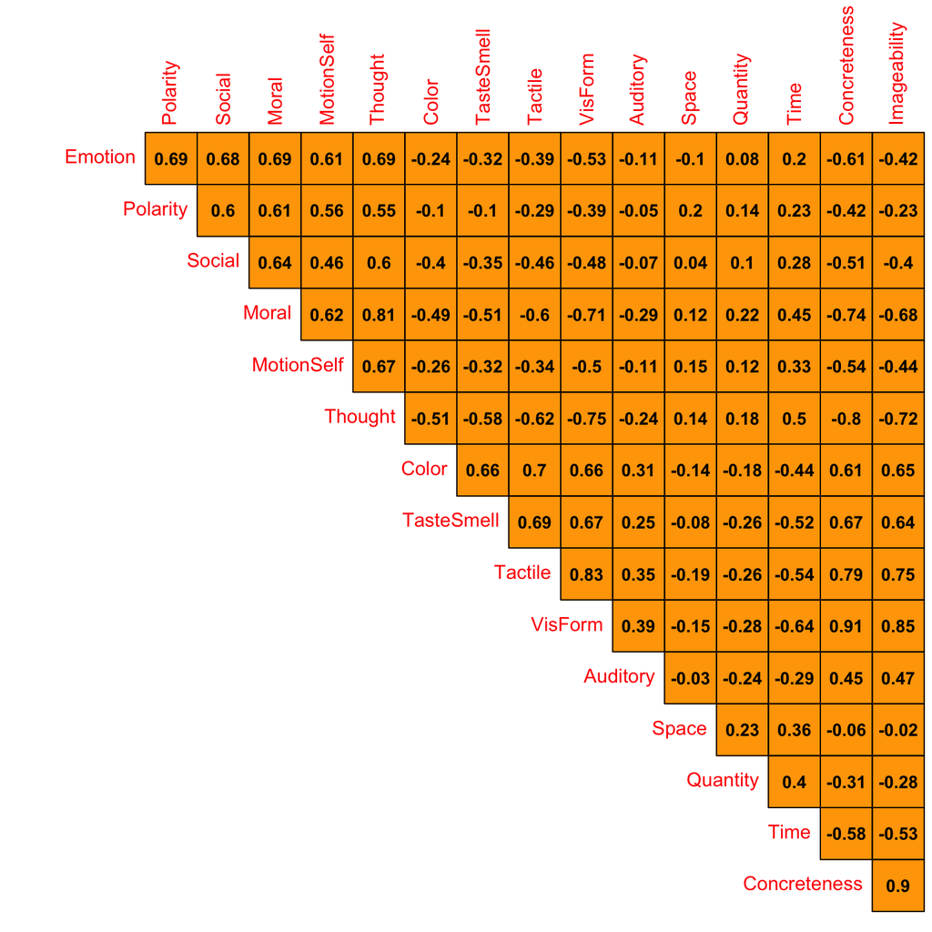

```r
corrplot(joshcor, method = "number", diag = F, type = "upper", bg = "orange",
    cl.pos = "n", number.cex = 0.9, col = "black", outline = T, number.digits = 2,
    addgrid.co = "black")
```

Generate the corrplot.

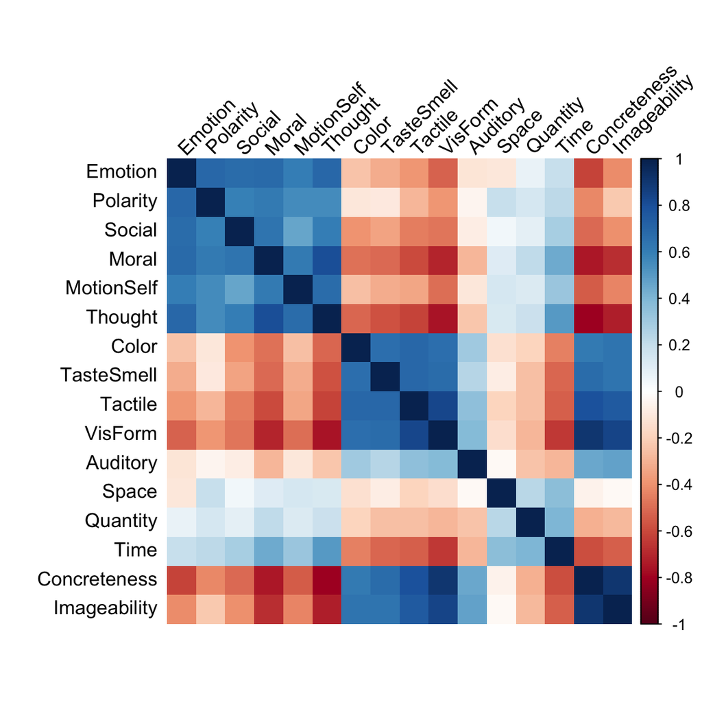

```r
corrplot(joshcor, method = "shade", shade.col = NA, tl.col = "black", tl.srt = 45)
```

## Corrplot varied by color and size

Here’s a correlation dotplot where the size of the circles indicate the strength of the correlation and the colors of the circles indicate the direction of the correlation (blue is negative, red is positive). Since this is a symmetrical matrix, I only included the upper diagonal.

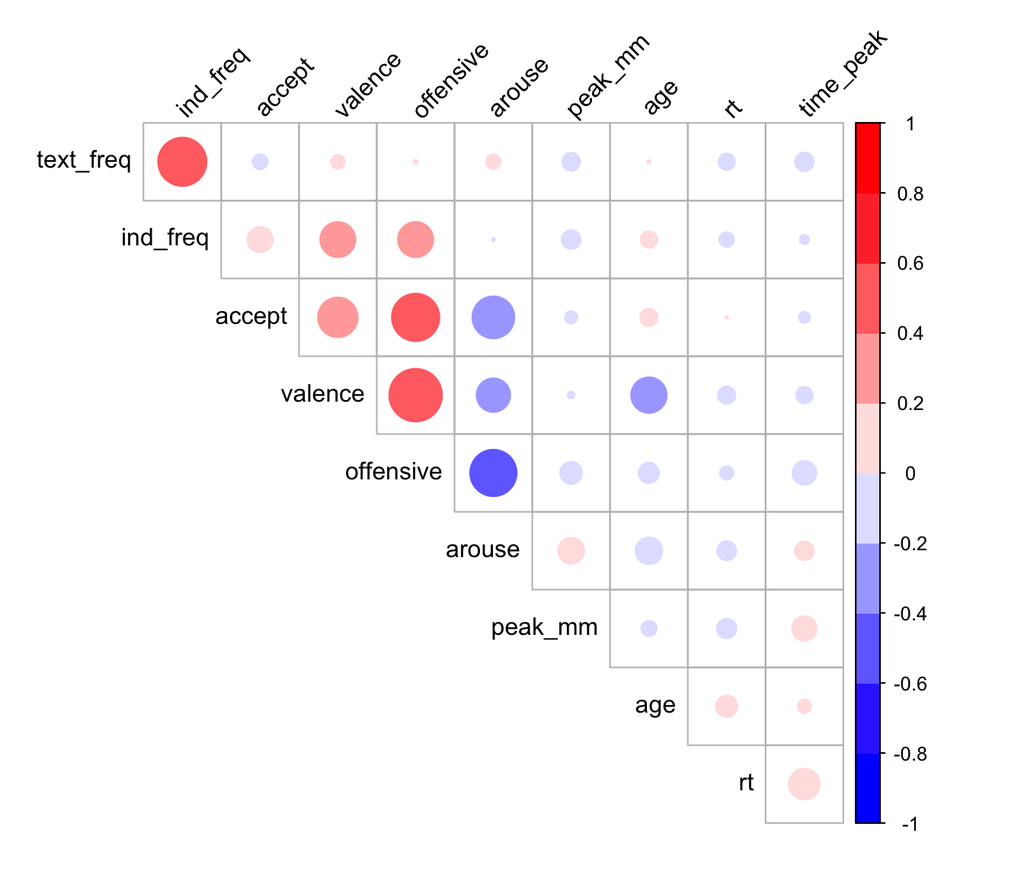

```r
corr <- read.csv("Exp1_Corrplot.csv", header = T)
corrmat <- cor(corr, use = "complete.obs")  #create a correlation matrix
colnew <- colorRampPalette(c("blue", "white", "red"))(10)  #creates a color palette ranging from blue to red in increments of 10
# generate a correlogram, upper only, by circle, color range by custom
# palette
corrplot(corrmat, method = "circle", type = "upper", tl.srt = 45, tl.cex = 1,
    tl.col = "black", col = colnew, diag = F, order = "hclust")
```

# Dendrograms

## Dendrogram: steps and considerations

```r
raw <- read.csv("Biling_Master_v10.csv", header = T)
raw_2 <- raw %>% select(8:9, 22:27)  #isolate only the columns of interest- dimensions, condition, participant
sp <- raw_2 %>% filter(Tag == "sp") %>% select(2:8)  #filters rows only corresponding to one condition 'sp' - spanish bilinguals
sp_means <- sp %>% group_by(Stim) %>% summarise_all(funs(mean(., na.rm = TRUE))) %>%
    as.data.frame()
head(sp_means, n = 8)
```

```
##          Stim Color Sound Morality Valence Size Position
## 1   advantage  1.65  1.60     2.70    3.10 2.80     2.20
## 2      advice  1.35  1.75     4.85    4.45 2.30     1.10
## 3 appointment  1.55  1.65     2.65    2.90 2.35     2.80
## 4 arrangement  2.00  1.55     2.90    2.55 1.40     1.30
## 5      beauty  3.10  2.00     4.55    4.75 3.40     1.70
## 6         bed  3.50  2.65     1.20    3.60 3.10     3.15
## 7    behavior  1.65  1.95     5.80    4.65 2.45     1.55
## 8        bird  4.90  5.20     1.35    2.05 2.90     2.20
```

Getting there. Now we must coerce the first row to rownames. Rownames get plotted as the dendrogram leaves.

```r
sp2 <- sp_means[, -1]  #create a new dataframe minus the first column (eliminate what will be rownames)
rownames(sp2) <- sp_means[, 1]  #coerce the first column (Word) into rownames of the dataframe
head(sp2, n = 8)
```

```
##             Color Sound Morality Valence Size Position
## advantage    1.65  1.60     2.70    3.10 2.80     2.20
## advice       1.35  1.75     4.85    4.45 2.30     1.10
## appointment  1.55  1.65     2.65    2.90 2.35     2.80
## arrangement  2.00  1.55     2.90    2.55 1.40     1.30
## beauty       3.10  2.00     4.55    4.75 3.40     1.70
## bed          3.50  2.65     1.20    3.60 3.10     3.15
## behavior     1.65  1.95     5.80    4.65 2.45     1.55
## bird         4.90  5.20     1.35    2.05 2.90     2.20
```

Now dendrogram it.

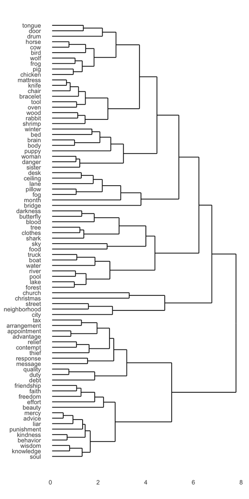

```r
sp.dend <- as.dendrogram(hclust(dist(sp2)))  #coverts to distance matrix, runs hierarchical cluster analysis using complete linkage
p <- ggdendrogram(sp.dend, rotate = TRUE)
print(p)
```

# Various Frankenplots: The Island of Lost Toys